# 20210412HW7_QE

Kinsey Reed

4/12/2021

Included in this homework is the same bobcat occupancy modeling dataset from homework 5: Bobcat.csv: detection / non-detection of bobcat at each camera. Each row is a camera, and each column is a replicate survey (1 day). p covariates.csv: number of people (divided by 100) photographed. Each row is a camera, and each column is a replicate survey (1 day). This is a detection covariate. psi covariates.csv: the single covariate represents the proportion of area within 5km recently disturbed (e.g., logging, housing development). Treat this as a site-level covariate.

1. Load data and place into an unmarkedFrameOccu object

```r
library(unmarked)
data <- read.csv('Bobcat.csv')
head(data)
```

```
##   day1 day2 day3 day4 day5 day6 day7 day8 day9 day10 day11 day12 day13 day14
## 1    0    0    0    0    0    0    0    0    0     0     0     0     0     0
## 2    0    0    0    0    0    0    0    0    0     0     0     0     0     0
## 3    0    0    0    0    0    0    0    0    0     0     0     0     0     0
## 4    0    0    0    0    0    0    0    0    0     0     0     0     0     0
## 5    0    0    0    0    0    0    0    0    0     0     0     0     0     0
## 6    0    0    0    0    0    0    0    0    0     0     0     0     0     0
##   day15 day16 day17 day18 day19 day20 day21 day22 day23 day24 day25 day26 day27
## 1     0     0     0     0     0     0     0     0    NA    NA    NA    NA    NA
## 2     0     0     0     0     0     0    NA    NA    NA    NA    NA    NA    NA
## 3    NA    NA    NA    NA    NA    NA    NA    NA    NA    NA    NA    NA    NA
## 4     0     0     0     0    NA    NA    NA    NA    NA    NA    NA    NA    NA
## 5     0     0     0     0     0     0     0    NA    NA    NA    NA    NA    NA
## 6     0     0     0     0     0     0     0    NA    NA    NA    NA    NA    NA
##   day28 day29 day30 day31 day32 day33 day34 day35 day36 day37 day38 day39 day40
```

[output cut: 27 more lines]

```r
p_covs <- read.csv('p covariates.csv')
site_covs <- read.csv('psi covariates.csv')

#In order to place into object:
#convert detection data to matrix
data_m <- as.matrix(data)
#for both covariates, make sure categorical variables are factors (none here though)
#detection covariates as a list of data.frames
class(p_covs)#already a data.frame
```

```
## [1] "data.frame"
```

```r
#put into list
det_covs <- list(
  people = p_covs
)

#site-level covariates just need to be a data.frame, which it already is
class(site_covs)
```

```
## [1] "data.frame"
```

```r
#put all into object
occu_data <- unmarkedFrameOccu(y = data,
                               siteCovs = site_covs,
                               obsCovs = det_covs)
```

2. Fit the following candidate set of models:

detection intercept-only + occupancy intercept-only

```r
fit1 <- occu(formula = ~ 1 ~ 1, data = occu_data)
summary(fit1)
```

```
##
## Call:
## occu(formula = ~1 ~ 1, data = occu_data)
##
## Occupancy (logit-scale):
##  Estimate     SE   z P(>|z|)
##     -1.32 0.0879 -15 7.6e-51
##
## Detection (logit-scale):
##  Estimate     SE     z P(>|z|)
##     -3.02 0.0734 -41.1       0
##
## AIC: 4490.771
## Number of sites: 1951
## optim convergence code: 0
## optim iterations: 29
## Bootstrap iterations: 0
```

detection people + occupancy intercept-only

```r
fit2 <- occu(formula = ~ people ~ 1, data = occu_data)
summary(fit2)
```

```
##
## Call:
## occu(formula = ~people ~ 1, data = occu_data)
##
## Occupancy (logit-scale):
##  Estimate     SE   z  P(>|z|)
##     -1.32 0.0879 -15 9.21e-51
##
## Detection (logit-scale):
##             Estimate     SE       z P(>|z|)
## (Intercept)  -3.0141 0.0743 -40.550   0.000
## people       -0.0765 0.3759  -0.203   0.839
##
## AIC: 4492.729
## Number of sites: 1951
## optim convergence code: 0
## optim iterations: 35
## Bootstrap iterations: 0
```

detection intercept-only + occupancy disturbance

```r
fit3 <- occu(formula = ~ 1 ~ Dist_5km, data = occu_data)
summary(fit3)
```

```
##
## Call:
## occu(formula = ~1 ~ Dist_5km, data = occu_data)
##
## Occupancy (logit-scale):
##             Estimate    SE      z  P(>|z|)
## (Intercept)    -1.05 0.101 -10.40 2.42e-25
## Dist_5km      -23.65 4.773  -4.96 7.23e-07
##
## Detection (logit-scale):
##  Estimate     SE     z P(>|z|)
##     -3.02 0.0732 -41.2       0
##
## AIC: 4461.006
## Number of sites: 1951
## optim convergence code: 0
## optim iterations: 52
## Bootstrap iterations: 0
```

detection people + occupancy disturbance

```r
fit4 <- occu(formula = ~ people ~ Dist_5km, data = occu_data)
summary(fit4)
```

```
##
## Call:
## occu(formula = ~people ~ Dist_5km, data = occu_data)
##
## Occupancy (logit-scale):
##             Estimate    SE      z  P(>|z|)
## (Intercept)    -1.05 0.101 -10.39 2.63e-25
## Dist_5km      -23.64 4.773  -4.95 7.28e-07
##
## Detection (logit-scale):
##             Estimate     SE       z P(>|z|)
## (Intercept)  -3.0133 0.0741 -40.646   0.000
## people       -0.0609 0.3779  -0.161   0.872
##
## AIC: 4462.98
## Number of sites: 1951
## optim convergence code: 0
## optim iterations: 39
## Bootstrap iterations: 0
```

3. Perform model selection with AIC. What is your top model? How do you know? Is there model selection uncertainty?

The top model is detection: intercept-only and occupancy: disturbance. We know because it is listed first and has a delta AIC = 0. However, the model that includes detection:people and occupancy:disturbance has a delta AIC < 2, so it also offers substantial empirical support for the top model. Because of this, there is model selection uncertainty.

```r
library(AICcmodavg)
cand.list <- list(
  IxI = fit1,
  PxI = fit2,
  IxD = fit3,
  PxD = fit4
)

models <- aictab(cand.set = cand.list, second.ord = F)
head(models)
```

```
##
## Model selection based on AIC:
##
##     K     AIC Delta_AIC AICWt Cum.Wt       LL
## IxD 3 4461.01      0.00  0.73   0.73 -2227.50
## PxD 4 4462.98      1.97  0.27   1.00 -2227.49
## IxI 2 4490.77     29.77  0.00   1.00 -2243.39
## PxI 3 4492.73     31.72  0.00   1.00 -2243.36
```

4. Average both the effect of people on detection, and disturbance on occupancy, over all models. Report model-averaged slope coefficients and 95% confidence intervals.

```r
#people on detection
avg_P <- modavgShrink(cand.set = cand.list,
             parm = 'people',
             second.ord = F,
             parm.type = 'detect'
             )
print("model averaged slope coefficient for the effect of people on detection")
```

```
## [1] "model averaged slope coefficient for the effect of people on detection"
```

```r
avg_P$Mod.avg.beta
```

```
## [1] -0.01653469
```

```r
print("model averaged 95% CI for the effect of people on detection")
```

```
## [1] "model averaged 95% CI for the effect of people on detection"
```

```r
avg_P$Lower.CL; avg_P$Upper.CL
```

```
## [1] -0.4061781
```

```
## [1] 0.3731087
```

```r
#disturbance on occupancy
avg_D <- modavgShrink(cand.set = cand.list,
                      parm = 'Dist_5km',
                      second.ord = F,
                      parm.type = 'psi')

print("model averaged slope coefficient for the effect of disturbance on occupancy")
```

```
## [1] "model averaged slope coefficient for the effect of disturbance on occupancy"
```

```r
avg_D$Mod.avg.beta
```

```
## [1] -23.65047
```

```r
print('model averaged 95% CI for the effect of disturbance on occupancy')
```

```
## [1] "model averaged 95% CI for the effect of disturbance on occupancy"
```

```r
avg_D$Lower.CL; avg_D$Upper.CL
```

```
## [1] -33.006
```

```
## [1] -14.29494
```

5. Obtain and plot model-averaged predictions of occupancy probability and detection probability. Average over all models, and make predictions over the observed range of each variable.

```r
new.df <- data.frame(
  people = seq(from = min(p_covs, na.rm = TRUE), to = max(p_covs, na.rm = TRUE), length.out = 100),
  Dist_5km = seq(from= min(site_covs$Dist_5km), to = max(site_covs$Dist_5km), length.out = 100)
)

predict_occu <- modavgPred(cand.set = cand.list,
                    newdata = new.df,
                    second.ord = F,
                    parm.type = 'psi')
predict_occu
```

```
##
## Model-averaged predictions on the response scale
## based on entire model set and 95% confidence interval:
##
##     mod.avg.pred uncond.se lower.CL upper.CL
## 1          0.260     0.019    0.224    0.300
## 2          0.254     0.019    0.219    0.292
## 3          0.248     0.018    0.215    0.285
## 4          0.242     0.017    0.210    0.278
## 5          0.237     0.017    0.206    0.271
## 6          0.231     0.016    0.201    0.264
## 7          0.226     0.016    0.196    0.258
## 8          0.220     0.015    0.192    0.252
## 9          0.215     0.015    0.187    0.246
## 10         0.210     0.015    0.182    0.241
```

[output cut: 90 more lines]

```r
predict_detect <- modavgPred(cand.set = cand.list,
                    newdata = new.df,
                    second.ord = F,
                    parm.type = 'detect')
predict_detect
```

```
##
## Model-averaged predictions on the response scale
## based on entire model set and 95% confidence interval:
##
##     mod.avg.pred uncond.se lower.CL upper.CL
## 1          0.047     0.003    0.041    0.054
## 2          0.047     0.003    0.041    0.054
## 3          0.047     0.003    0.041    0.054
## 4          0.047     0.003    0.040    0.054
## 5          0.047     0.004    0.040    0.054
## 6          0.047     0.004    0.039    0.055
## 7          0.047     0.004    0.039    0.056
## 8          0.046     0.005    0.038    0.056
## 9          0.046     0.005    0.038    0.057
## 10         0.046     0.005    0.037    0.058
```

[output cut: 90 more lines]

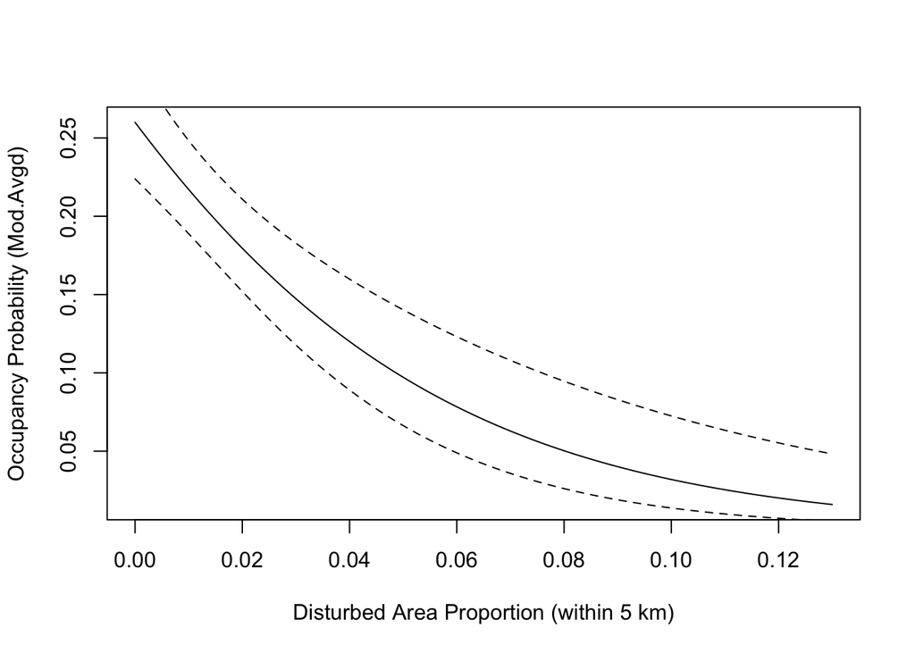

```r
plot(y = predict_occu$mod.avg.pred,
     x=new.df$Dist_5km,
     type = 'l',
     ylab = 'Occupancy Probability (Mod.Avgd)',
     xlab='Disturbed Area Proportion (within 5 km)'
     )
lines(x = new.df$Dist_5km, y = predict_occu$lower.CL, lty = 2)
lines(x = new.df$Dist_5km, y = predict_occu$upper.CL, lty = 2)
```

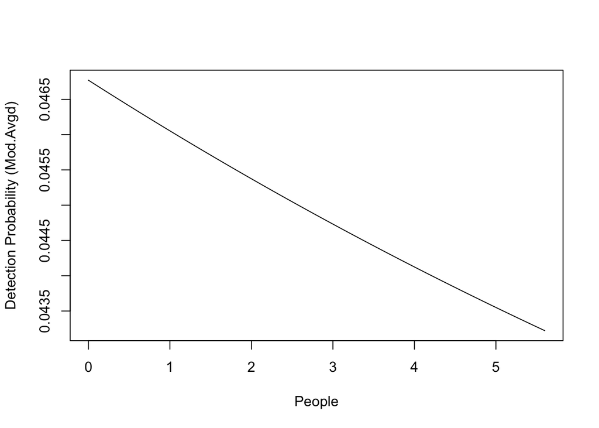

```r
plot(y = predict_detect$mod.avg.pred,
     x=new.df$people,
     type = 'l',
     ylab = 'Detection Probability (Mod.Avgd)',
     xlab='People'
     )
lines(x = new.df$people, y = predict_detect$lower.CL, lty = 2)
lines(x = new.df$people, y = predict_detect$upper.CL, lty = 2)
```

```r
#really small confidence intervals?
```